# Assignment_4_2

2023-04-05

1. (2p) explore the overall structure of the dataset using the str() function. Get a summary statistics of each variable. Answer the following questions: o How many observations do you have in the data? o What is the type of each variable? Categorical ( nominal or ordinal) or continuous? o Is there any missing value? o Draw the histogram of count. Interpret what you see in the histogram

```r
bike_dataset = read.csv("C:/ML/bike.csv", header = TRUE)

summary(bike_dataset)
```

```
##    datetime             season         holiday          workingday
##  Length:10886       Min.   :1.000   Min.   :0.00000   Min.   :0.0000
##  Class :character   1st Qu.:2.000   1st Qu.:0.00000   1st Qu.:0.0000
##  Mode  :character   Median :3.000   Median :0.00000   Median :1.0000
##                     Mean   :2.507   Mean   :0.02857   Mean   :0.6809
##                     3rd Qu.:4.000   3rd Qu.:0.00000   3rd Qu.:1.0000
##                     Max.   :4.000   Max.   :1.00000   Max.   :1.0000
##     weather           temp           atemp          humidity
##  Min.   :1.000   Min.   : 0.82   Min.   : 0.76   Min.   :  0.00
##  1st Qu.:1.000   1st Qu.:13.94   1st Qu.:16.66   1st Qu.: 47.00
##  Median :1.000   Median :20.50   Median :24.24   Median : 62.00
##  Mean   :1.418   Mean   :20.23   Mean   :23.66   Mean   : 61.89
##  3rd Qu.:2.000   3rd Qu.:26.24   3rd Qu.:31.06   3rd Qu.: 77.00
##  Max.   :4.000   Max.   :41.00   Max.   :45.45   Max.   :100.00
##    windspeed          casual         registered        count
##  Min.   : 0.000   Min.   :  0.00   Min.   :  0.0   Min.   :  1.0
##  1st Qu.: 7.002   1st Qu.:  4.00   1st Qu.: 36.0   1st Qu.: 42.0
##  Median :12.998   Median : 17.00   Median :118.0   Median :145.0
##  Mean   :12.799   Mean   : 36.02   Mean   :155.6   Mean   :191.6
##  3rd Qu.:16.998   3rd Qu.: 49.00   3rd Qu.:222.0   3rd Qu.:284.0
##  Max.   :56.997   Max.   :367.00   Max.   :886.0   Max.   :977.0
```

```r
str(bike_dataset)
```

```
## 'data.frame':    10886 obs. of  12 variables:
##  $ datetime  : chr  "2011-01-01 00:00:00" "2011-01-01 01:00:00" "2011-01-01 02:00:00" "2011-01-01 03:00:00" ...
##  $ season    : int  1 1 1 1 1 1 1 1 1 1 ...
##  $ holiday   : int  0 0 0 0 0 0 0 0 0 0 ...
##  $ workingday: int  0 0 0 0 0 0 0 0 0 0 ...
##  $ weather   : int  1 1 1 1 1 2 1 1 1 1 ...
##  $ temp      : num  9.84 9.02 9.02 9.84 9.84 ...
##  $ atemp     : num  14.4 13.6 13.6 14.4 14.4 ...
##  $ humidity  : int  81 80 80 75 75 75 80 86 75 76 ...
##  $ windspeed : num  0 0 0 0 0 ...
##  $ casual    : int  3 8 5 3 0 0 2 1 1 8 ...
##  $ registered: int  13 32 27 10 1 1 0 2 7 6 ...
##  $ count     : int  16 40 32 13 1 1 2 3 8 14 ...
```

There are 10886 observations in the data.

datetime: character season: integer (categorical) holiday: integer (categorical) workingday: integer (categorical) weather: integer (categorical) temp: numeric (continuous) atemp: numeric (continuous) humidity: integer (continuous) windspeed: numeric (continuous) casual: integer (continuous) registered: integer (continuous) count: integer (continuous)

```r
sum(is.na(bike_dataset))
```

```
## [1] 0
```

There is no missing values.

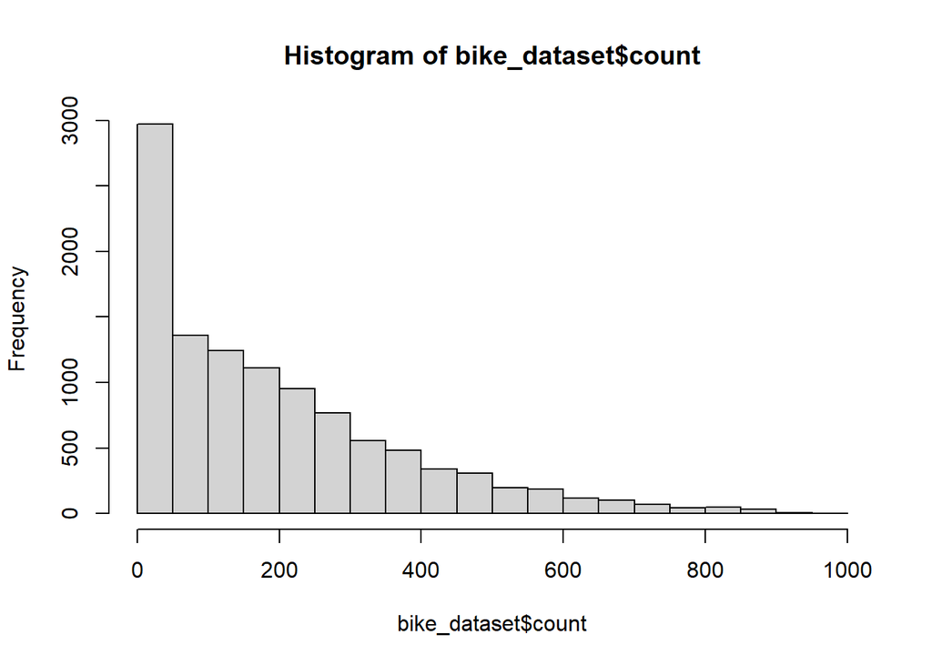

```r
#install.packages("ggplot2")
library(ggplot2)

#ggplot(bike_dataset, aes(x = count)) + geom_histogram(binwidth = 50)

hist(bike_dataset$count)
```

2. Remove the “registered” and “casual” variables. These are the count of registered and casual users and together they can perfectly predict “count” so we are removing them from the model and predict count from the other features

```r
bike_dataset = subset(bike_dataset, select = -c(registered,casual) )

str(bike_dataset)
```

```
## 'data.frame':    10886 obs. of  10 variables:
##  $ datetime  : chr  "2011-01-01 00:00:00" "2011-01-01 01:00:00" "2011-01-01 02:00:00" "2011-01-01 03:00:00" ...
##  $ season    : int  1 1 1 1 1 1 1 1 1 1 ...
##  $ holiday   : int  0 0 0 0 0 0 0 0 0 0 ...
##  $ workingday: int  0 0 0 0 0 0 0 0 0 0 ...
##  $ weather   : int  1 1 1 1 1 2 1 1 1 1 ...
##  $ temp      : num  9.84 9.02 9.02 9.84 9.84 ...
##  $ atemp     : num  14.4 13.6 13.6 14.4 14.4 ...
##  $ humidity  : int  81 80 80 75 75 75 80 86 75 76 ...
##  $ windspeed : num  0 0 0 0 0 ...
##  $ count     : int  16 40 32 13 1 1 2 3 8 14 ...
```

3. (1p) The count variable is severely right-skewed. A skewed target variable can make a machine learning model biased. For instance, in this case lower counts are more frequent in the training data compared to higher counts . Therefore, a machine learning model trained on this data is less likely to successfully predict higher counts. There are different ways we can transform a right-skewed variable to a more bell-shape distribution. Common transformations for a right-skewed data includes log, square-root and cube-root transformations. We are going to use square root transformation here to make the distribution of count more bell-shaped. Set the count variable in your dataframe equal to square root of count and plot its distribution again.

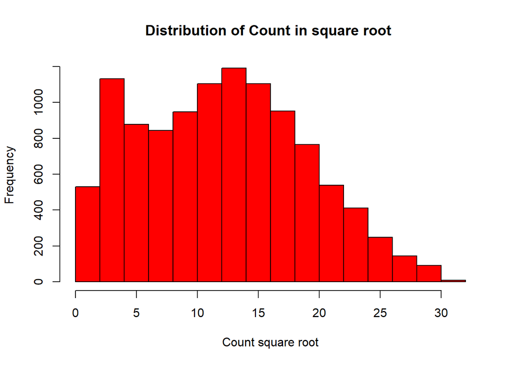

```r
bike_dataset$count = sqrt(bike_dataset$count)
hist(bike_dataset$count, col = "red", xlab = "Count square root", main = "Distribution of Count in square root ")
```

in the above we used the square root transformation

4. (2 pt) Variable datetime is not useful in its current form. Convert this variable to “day of month”, “year”, “day of week”, ”month” and “hour” variables. You can use as.POSIXlt function to extract those features from datetime. Please see this reference for an example.Remove the original datetime variable after conversion.

```r
# Convert character data to date and time.
#bike_dataset$datetime = as.POSIXct("2015-10-19 10:15")
#str(bike_dataset$datetime)

# view sample data
head(bike_dataset$datetime)
```

```
## [1] "2011-01-01 00:00:00" "2011-01-01 01:00:00" "2011-01-01 02:00:00"
## [4] "2011-01-01 03:00:00" "2011-01-01 04:00:00" "2011-01-01 05:00:00"
```

```r
# Convert character data to POSIXlt date and time
#timeDatelt<- as.POSIXlt("2015-10-19 10:15")
#str(timeDatelt)

#bike_dataset$datetime = as.POSIXlt(""%Y-%m-%d %H:%M:%S"")
#str(bike_dataset$datetime)

bike_dataset$datetime <- as.POSIXlt(bike_dataset$datetime, format = "%Y-%m-%d %H:%M:%S")
str(bike_dataset$datetime)
```

```
##  POSIXlt[1:10886], format: "2011-01-01 00:00:00" "2011-01-01 01:00:00" "2011-01-01 02:00:00" ...
```

```r
#bike_dataset$datetime

unclass(bike_dataset$datetime)
```

[output not shown]

[output cut: 5152 more lines]

```r
sum(is.na(bike_dataset$datetime$gmtoff))
```

```
## [1] 10886
```

```r
sum(is.na(bike_dataset$datetime))
```

```
## [1] 0
```

```r
bike_dataset$year = bike_dataset$datetime$year + 1900
bike_dataset$month = bike_dataset$datetime$mon + 1
bike_dataset$day = bike_dataset$datetime$mday
bike_dataset$hour = bike_dataset$datetime$hour
bike_dataset$dayofaweek = bike_dataset$datetime$wday
```

```r
bike_dataset = subset(bike_dataset, select = -c(datetime) )

str(bike_dataset)
```

```
## 'data.frame':    10886 obs. of  14 variables:
##  $ season    : int  1 1 1 1 1 1 1 1 1 1 ...
##  $ holiday   : int  0 0 0 0 0 0 0 0 0 0 ...
##  $ workingday: int  0 0 0 0 0 0 0 0 0 0 ...
##  $ weather   : int  1 1 1 1 1 2 1 1 1 1 ...
##  $ temp      : num  9.84 9.02 9.02 9.84 9.84 ...
##  $ atemp     : num  14.4 13.6 13.6 14.4 14.4 ...
##  $ humidity  : int  81 80 80 75 75 75 80 86 75 76 ...
##  $ windspeed : num  0 0 0 0 0 ...
##  $ count     : num  4 6.32 5.66 3.61 1 ...
##  $ year      : num  2011 2011 2011 2011 2011 ...
##  $ month     : num  1 1 1 1 1 1 1 1 1 1 ...
##  $ day       : int  1 1 1 1 1 1 1 1 1 1 ...
##  $ hour      : int  0 1 2 3 4 5 6 7 8 9 ...
##  $ dayofaweek: int  6 6 6 6 6 6 6 6 6 6 ...
```

```r
sum(is.na(bike_dataset))
```

```
## [1] 0
```

5. (3pt) Variables “month”, “day of week”, “hour”, and “season” are categorical but they are also circular. This means these variables are periodic in nature. If we represent a circular variable like “month” with numeric indices 0-11 we are implying that the distance between month 10 (November) and month 11 (December) is much lower than the distance between month 11(December) and month 0 (January) which is not correct. At the other hand if we one-hotencode the “month” variable we are ignoring the chronological ordering between month values and assume that the distance between every two months is equal. A better way to represent these variables is to map each value into a point in a circle where the lowest value appears next to the largest value in the circle. For instance, we can transform the “month” variable by creating “x” and “y” coordinates of the point in such circle using sin and cosine transformations as follows

```r
bike_dataset$x_month = cos(2*pi*bike_dataset$month/max(bike_dataset$month))
bike_dataset$y_month = sin(2*pi*bike_dataset$month/max(bike_dataset$month))

bike_dataset$x_dayofaweek=cos(2*pi*bike_dataset$dayofaweek/max(bike_dataset$dayofaweek))
bike_dataset$y_dayofaweek=sin(2*pi*bike_dataset$dayofaweek/max(bike_dataset$dayofaweek))

bike_dataset$x_hour = cos(2*pi*bike_dataset$hour/max(bike_dataset$hour))
bike_dataset$y_hour = sin(2*pi*bike_dataset$hour/max(bike_dataset$hour))

bike_dataset$x_season = cos(2*pi*bike_dataset$season/max(bike_dataset$season))
bike_dataset$y_season = sin(2*pi*bike_dataset$season/max(bike_dataset$season))

bike_dataset$day = as.numeric(bike_dataset$day)
```

```r
bike_dataset = subset(bike_dataset, select = -c(month,dayofaweek,hour,season) )
str(bike_dataset)
```

```
## 'data.frame':    10886 obs. of  18 variables:
##  $ holiday     : int  0 0 0 0 0 0 0 0 0 0 ...
##  $ workingday  : int  0 0 0 0 0 0 0 0 0 0 ...
##  $ weather     : int  1 1 1 1 1 2 1 1 1 1 ...
##  $ temp        : num  9.84 9.02 9.02 9.84 9.84 ...
##  $ atemp       : num  14.4 13.6 13.6 14.4 14.4 ...
##  $ humidity    : int  81 80 80 75 75 75 80 86 75 76 ...
##  $ windspeed   : num  0 0 0 0 0 ...
##  $ count       : num  4 6.32 5.66 3.61 1 ...
##  $ year        : num  2011 2011 2011 2011 2011 ...
##  $ day         : num  1 1 1 1 1 1 1 1 1 1 ...
##  $ x_month     : num  0.866 0.866 0.866 0.866 0.866 ...
##  $ y_month     : num  0.5 0.5 0.5 0.5 0.5 0.5 0.5 0.5 0.5 0.5 ...
##  $ x_dayofaweek: num  1 1 1 1 1 1 1 1 1 1 ...
##  $ y_dayofaweek: num  -2.45e-16 -2.45e-16 -2.45e-16 -2.45e-16 -2.45e-16 ...
##  $ x_hour      : num  1 0.963 0.854 0.683 0.46 ...
##  $ y_hour      : num  0 0.27 0.52 0.731 0.888 ...
##  $ x_season    : num  6.12e-17 6.12e-17 6.12e-17 6.12e-17 6.12e-17 ...
##  $ y_season    : num  1 1 1 1 1 1 1 1 1 1 ...
```

```r
#install.packages("mltools")
library(mltools)
library(data.table)


bike_d = bike_dataset[, c('weather', 'temp', 'atemp', 'humidity', 'windspeed', 'year', 'day', 'x_month', 'y_month', 'x_dayofaweek', 'y_dayofaweek', 'x_hour', 'y_hour', 'x_season', 'y_season')]
bike_d = one_hot((bike_d))

bike_d$holiday = bike_dataset$holiday
bike_d$workingday = bike_dataset$workingday


#bike_y = bike_dataset$count

#bike_y$count = bike_dataset$count

#bike_y = data.frame(count = bike_dataset$count)

bike_d$count = bike_dataset$count
```

```r
str(bike_d)
```

```
## 'data.frame':    10886 obs. of  18 variables:
##  $ weather     : int  1 1 1 1 1 2 1 1 1 1 ...
##  $ temp        : num  9.84 9.02 9.02 9.84 9.84 ...
##  $ atemp       : num  14.4 13.6 13.6 14.4 14.4 ...
##  $ humidity    : int  81 80 80 75 75 75 80 86 75 76 ...
##  $ windspeed   : num  0 0 0 0 0 ...
##  $ year        : num  2011 2011 2011 2011 2011 ...
##  $ day         : num  1 1 1 1 1 1 1 1 1 1 ...
##  $ x_month     : num  0.866 0.866 0.866 0.866 0.866 ...
##  $ y_month     : num  0.5 0.5 0.5 0.5 0.5 0.5 0.5 0.5 0.5 0.5 ...
##  $ x_dayofaweek: num  1 1 1 1 1 1 1 1 1 1 ...
##  $ y_dayofaweek: num  -2.45e-16 -2.45e-16 -2.45e-16 -2.45e-16 -2.45e-16 ...
##  $ x_hour      : num  1 0.963 0.854 0.683 0.46 ...
##  $ y_hour      : num  0 0.27 0.52 0.731 0.888 ...
##  $ x_season    : num  6.12e-17 6.12e-17 6.12e-17 6.12e-17 6.12e-17 ...
##  $ y_season    : num  1 1 1 1 1 1 1 1 1 1 ...
##  $ holiday     : int  0 0 0 0 0 0 0 0 0 0 ...
##  $ workingday  : int  0 0 0 0 0 0 0 0 0 0 ...
##  $ count       : num  4 6.32 5.66 3.61 1 ...
```

```r
#str(bike_y)
```

8. Use Caret’s “createDataPartition” method as follows to partition the dataset into bikes_train, and bikes_test (use 90% for training and 10% for testing)

```r
library(caret)
inTrain = createDataPartition(bike_d$count, p = 0.9, list = FALSE)

bike_train = bike_d[inTrain, ]
bike_test = bike_d[-inTrain, ]

#bike_train_y = bike_y[inTrain, ]
#bike_test_y = bike_y[-inTrain, ]
```

```r
dim(bike_train)
```

```
## [1] 9799   18
```

```r
dim(bike_test)
```

```
## [1] 1087   18
```

9. (1pt) Set.seed(1) and further divide the bikes_train data into 90% training and 10% validation using Caret’s “CreateDataPartition” function.

```r
#dim(bike_train_y)
```

```r
# library(caret)
#
# set.seed(1)
#
# inTrain = createDataPartition(bike_train_y$count, p = 0.9, list = FALSE)
# bike_train_x_2 = bike_train_x[inTrain,]
# bike_val_x = bike_train_x[-inTrain,]
#
# bike_train_y_2 = bike_train_y[inTrain,]
# bike_val_y = bike_train_y[-inTrain,]

library(caret)
set.seed(1)

inTrain = createDataPartition(bike_train$count, p = 0.9, list = FALSE)
bike_train_new = bike_train[inTrain, ]
bike_validation = bike_train[-inTrain, ]
```

```r
dim(bike_train_new)
```

```
## [1] 8821   18
```

```r
dim(bike_validation)
```

```
## [1] 978  18
```

```r
names(bike_train_new)
```

```
##  [1] "weather"      "temp"         "atemp"        "humidity"     "windspeed"
##  [6] "year"         "day"          "x_month"      "y_month"      "x_dayofaweek"
## [11] "y_dayofaweek" "x_hour"       "y_hour"       "x_season"     "y_season"
## [16] "holiday"      "workingday"   "count"
```

```r
names(bike_validation)
```

```
##  [1] "weather"      "temp"         "atemp"        "humidity"     "windspeed"
##  [6] "year"         "day"          "x_month"      "y_month"      "x_dayofaweek"
## [11] "y_dayofaweek" "x_hour"       "y_hour"       "x_season"     "y_season"
## [16] "holiday"      "workingday"   "count"
```

```r
names(bike_test)
```

```
##  [1] "weather"      "temp"         "atemp"        "humidity"     "windspeed"
##  [6] "year"         "day"          "x_month"      "y_month"      "x_dayofaweek"
## [11] "y_dayofaweek" "x_hour"       "y_hour"       "x_season"     "y_season"
## [16] "holiday"      "workingday"   "count"
```

```r
str(bike_train_new)
```

```
## 'data.frame':    8821 obs. of  18 variables:
##  $ weather     : int  1 1 1 1 1 1 1 1 1 1 ...
##  $ temp        : num  9.84 9.02 9.02 9.84 9.84 ...
##  $ atemp       : num  14.4 13.6 13.6 14.4 14.4 ...
##  $ humidity    : int  81 80 80 75 75 80 86 75 76 76 ...
##  $ windspeed   : num  0 0 0 0 0 ...
##  $ year        : num  2011 2011 2011 2011 2011 ...
##  $ day         : num  1 1 1 1 1 1 1 1 1 1 ...
##  $ x_month     : num  0.866 0.866 0.866 0.866 0.866 ...
##  $ y_month     : num  0.5 0.5 0.5 0.5 0.5 0.5 0.5 0.5 0.5 0.5 ...
##  $ x_dayofaweek: num  1 1 1 1 1 1 1 1 1 1 ...
##  $ y_dayofaweek: num  -2.45e-16 -2.45e-16 -2.45e-16 -2.45e-16 -2.45e-16 ...
##  $ x_hour      : num  1 0.963 0.854 0.683 0.46 ...
##  $ y_hour      : num  0 0.27 0.52 0.731 0.888 ...
##  $ x_season    : num  6.12e-17 6.12e-17 6.12e-17 6.12e-17 6.12e-17 ...
##  $ y_season    : num  1 1 1 1 1 1 1 1 1 1 ...
##  $ holiday     : int  0 0 0 0 0 0 0 0 0 0 ...
##  $ workingday  : int  0 0 0 0 0 0 0 0 0 0 ...
##  $ count       : num  4 6.32 5.66 3.61 1 ...
```

```r
numeric_cols = c("weather", "temp", "atemp", "humidity", "windspeed", "year", "day", "holiday", "workingday")

col_means_train=attr(scale(bike_train_new [,numeric_cols]), "scaled:center")
col_stddevs_train=attr( scale(bike_train_new[,numeric_cols]), "scaled:scale")


bike_train_new[numeric_cols]= scale(bike_train_new[numeric_cols])
bike_test[numeric_cols]=scale(bike_test[numeric_cols], center = col_means_train, scale =col_stddevs_train)

bike_train_new[numeric_cols]= scale(bike_train_new[numeric_cols])
bike_validation[numeric_cols]=scale(bike_validation[numeric_cols], center = col_means_train, scale =col_stddevs_train)
```

```r
str(bike_train_new)
```

```
## 'data.frame':    8821 obs. of  18 variables:
##  $ weather     : num  -0.661 -0.661 -0.661 -0.661 -0.661 ...
##  $ temp        : num  -1.34 -1.44 -1.44 -1.34 -1.34 ...
##  $ atemp       : num  -1.1 -1.19 -1.19 -1.1 -1.1 ...
##  $ humidity    : num  0.997 0.945 0.945 0.685 0.685 ...
##  $ windspeed   : num  -1.56 -1.56 -1.56 -1.56 -1.56 ...
##  $ year        : num  -1 -1 -1 -1 -1 ...
##  $ day         : num  -1.64 -1.64 -1.64 -1.64 -1.64 ...
##  $ x_month     : num  0.866 0.866 0.866 0.866 0.866 ...
##  $ y_month     : num  0.5 0.5 0.5 0.5 0.5 0.5 0.5 0.5 0.5 0.5 ...
##  $ x_dayofaweek: num  1 1 1 1 1 1 1 1 1 1 ...
##  $ y_dayofaweek: num  -2.45e-16 -2.45e-16 -2.45e-16 -2.45e-16 -2.45e-16 ...
##  $ x_hour      : num  1 0.963 0.854 0.683 0.46 ...
##  $ y_hour      : num  0 0.27 0.52 0.731 0.888 ...
##  $ x_season    : num  6.12e-17 6.12e-17 6.12e-17 6.12e-17 6.12e-17 ...
##  $ y_season    : num  1 1 1 1 1 1 1 1 1 1 ...
##  $ holiday     : num  -0.172 -0.172 -0.172 -0.172 -0.172 ...
##  $ workingday  : num  -1.47 -1.47 -1.47 -1.47 -1.47 ...
##  $ count       : num  4 6.32 5.66 3.61 1 ...
```

```r
str(bike_test)
```

```
## 'data.frame':    1087 obs. of  18 variables:
##  $ weather     : num  0.916 0.916 2.493 -0.661 -0.661 ...
##  $ temp        : num  -0.178 -0.283 -0.706 -0.811 -1.339 ...
##  $ atemp       : num  -0.111 -0.2 -0.738 -0.828 -1.455 ...
##  $ humidity    : num  1.361 1.672 0.737 -0.249 -1.651 ...
##  $ windspeed   : num  0.8777 0.5111 0.0226 0.0226 0.2672 ...
##  $ year        : num  -1 -1 -1 -1 -1 ...
##  $ day         : num  -1.64 -1.46 -1.46 -1.46 -1.28 ...
##  $ x_month     : num  0.866 0.866 0.866 0.866 0.866 ...
##  $ y_month     : num  0.5 0.5 0.5 0.5 0.5 0.5 0.5 0.5 0.5 0.5 ...
##  $ x_dayofaweek: num  1 1 1 1 0.5 -0.5 -0.5 -1 -0.5 -0.5 ...
##  $ y_dayofaweek: num  -2.45e-16 0.00 0.00 0.00 8.66e-01 ...
##  $ x_hour      : num  1 0.9629 -0.7757 -0.0682 -0.0682 ...
##  $ y_hour      : num  -2.45e-16 2.70e-01 -6.31e-01 -9.98e-01 -9.98e-01 ...
##  $ x_season    : num  6.12e-17 6.12e-17 6.12e-17 6.12e-17 6.12e-17 ...
##  $ y_season    : num  1 1 1 1 1 1 1 1 1 1 ...
##  $ holiday     : num  -0.172 -0.172 -0.172 -0.172 -0.172 ...
##  $ workingday  : num  -1.475 -1.475 -1.475 -1.475 0.678 ...
##  $ count       : num  6.24 4.12 7.68 8.06 12.53 ...
```

```r
str(bike_validation)
```

```
## 'data.frame':    978 obs. of  18 variables:
##  $ weather     : num  0.916 -0.661 0.916 0.916 -0.661 ...
##  $ temp        : num  -1.339 -0.389 -0.706 -0.706 -1.022 ...
##  $ atemp       : num  -1.275 -0.29 -0.738 -0.828 -1.186 ...
##  $ humidity    : num  0.685 0.789 0.997 0.218 -1.184 ...
##  $ windspeed   : num  -0.832 0.756 0.267 0.878 1.366 ...
##  $ year        : num  -1 -1 -1 -1 -1 ...
##  $ day         : num  -1.64 -1.64 -1.46 -1.46 -1.46 ...
##  $ x_month     : num  0.866 0.866 0.866 0.866 0.866 ...
##  $ y_month     : num  0.5 0.5 0.5 0.5 0.5 0.5 0.5 0.5 0.5 0.5 ...
##  $ x_dayofaweek: num  1 1 1 1 1 0.5 0.5 -0.5 -0.5 -1 ...
##  $ y_dayofaweek: num  -2.45e-16 -2.45e-16 0.00 0.00 0.00 ...
##  $ x_hour      : num  0.203 -0.991 -0.917 -0.991 0.683 ...
##  $ y_hour      : num  0.979 -0.136 0.398 -0.136 -0.731 ...
##  $ x_season    : num  6.12e-17 6.12e-17 6.12e-17 6.12e-17 6.12e-17 ...
##  $ y_season    : num  1 1 1 1 1 1 1 1 1 1 ...
##  $ holiday     : num  -0.172 -0.172 -0.172 -0.172 -0.172 ...
##  $ workingday  : num  -1.47 -1.47 -1.47 -1.47 -1.47 ...
##  $ count       : num  1 9.17 7.28 9.64 4.69 ...
```

```r
names(bike_train_new)
```

```
##  [1] "weather"      "temp"         "atemp"        "humidity"     "windspeed"
##  [6] "year"         "day"          "x_month"      "y_month"      "x_dayofaweek"
## [11] "y_dayofaweek" "x_hour"       "y_hour"       "x_season"     "y_season"
## [16] "holiday"      "workingday"   "count"
```

```r
names(bike_test)
```

```
##  [1] "weather"      "temp"         "atemp"        "humidity"     "windspeed"
##  [6] "year"         "day"          "x_month"      "y_month"      "x_dayofaweek"
## [11] "y_dayofaweek" "x_hour"       "y_hour"       "x_season"     "y_season"
## [16] "holiday"      "workingday"   "count"
```

```r
names(bike_validation)
```

```
##  [1] "weather"      "temp"         "atemp"        "humidity"     "windspeed"
##  [6] "year"         "day"          "x_month"      "y_month"      "x_dayofaweek"
## [11] "y_dayofaweek" "x_hour"       "y_hour"       "x_season"     "y_season"
## [16] "holiday"      "workingday"   "count"
```

```r
# install.packages("keras")
# library(keras)
# #install_keras()
# library("keras")

#model = keras_model_sequential()
```

```r
#install.packages("magrittr") # package installations are only needed the first time you use it
#install.packages("dplyr")    # alternative installation of the %>%
library(magrittr) # needs to be run every time you start R and want to use %>%
library(dplyr)
#install.packages("keras")
library(keras)
#install_keras()
library("keras")
```

```r
library(reticulate)
#path_to_python <- install_python()
#virtualenv_create("r-reticulate", python = path_to_python)

library(tensorflow)
#install_tensorflow(envname = "r-reticulate")
```

```r
#install.packages("keras")
library(keras)
#install_keras(envname = "r-reticulate")
```

```r
library(tensorflow)
tf$constant("Hello Tensorflow!")
```

```
## tf.Tensor(b'Hello Tensorflow!', shape=(), dtype=string)
```

```r
# #install.packages("devtools")
# library(devtools)
# #
# devtools::install_github("rstudio/tensorflow")
# devtools::install_github("rstudio/keras")
# #
# tensorflow::install_tensorflow()
# tensorflow::tf_config()
#
# #install.packages("tensorflow")
# library(tensorflow)
# #install_tensorflow()

#install.packages("tfruns")
```

```r
set.seed(1)
train_bike_x <- bike_train_new[, -18]
train_bike_y <- bike_train_new[, 18]
val_bike_x <- bike_validation[,-18]
val_bike_y <- bike_validation[, 18]
test_bike_x <- bike_test[, -18]
test_bike_y <- bike_test[, 18]
```

```r
dim(train_bike_x)
```

```
## [1] 8821   17
```

```r
dim(val_bike_x)
```

```
## [1] 978  17
```

```r
dim(test_bike_x)
```

```
## [1] 1087   17
```

```r
# names(train_labels)
#dim(train_bike_y)
str(train_bike_y)
```

```
##  num [1:8821] 4 6.32 5.66 3.61 1 ...
```

```r
str(val_bike_y)
```

```
##  num [1:978] 1 9.17 7.28 9.64 4.69 ...
```

```r
str(test_bike_y)
```

```
##  num [1:1087] 6.24 4.12 7.68 8.06 12.53 ...
```

11. (5 pt) Create an ANN model to predict count from other attributes. Use at least two hidden layers. Use tfruns to tune your model’s hyper-parameters including, the number of nodes in each hidden layer, the activation function in each hidden layer, batch_size, learning_rate, and the number of epochs). Validate each model on the validation set.

```r
library(keras)
library(tensorflow)
library(tfruns)

set.seed(2)
#install.packages("tfruns")
library(keras)
library(tfruns)

FLAGS <- flags(
  flag_numeric("nodes", 8),
  flag_numeric("batch_size", 10),
  flag_string("activation", "relu"),
  flag_numeric("learning_rate", 0.01),
  flag_numeric("epochs", 30)
)

model =keras_model_sequential()

model %>%
  layer_dense(units=128, activation="relu", input_shape=dim(train_bike_x)[2])%>%
  layer_dropout(0.2)%>%
  layer_dense(units=128, activation="relu")%>%
  layer_dropout(0.2) %>%
  layer_dense(units=1)



model
```

```
## Model: "sequential"
## ________________________________________________________________________________
##  Layer (type)                       Output Shape                    Param #
## ================================================================================
##  dense_2 (Dense)                    (None, 128)                     2304
##  dropout_1 (Dropout)                (None, 128)                     0
##  dense_1 (Dense)                    (None, 128)                     16512
##  dropout (Dropout)                  (None, 128)                     0
##  dense (Dense)                      (None, 1)                       129
## ================================================================================
## Total params: 18,945
## Trainable params: 18,945
## Non-trainable params: 0
## ________________________________________________________________________________
```

```r
model %>% compile(
  loss = "mse",
  optimizer = "adam",
  metrics = list("mean_absolute_error")
)

model %>% summary()
```

```
## Model: "sequential"
## ________________________________________________________________________________
##  Layer (type)                       Output Shape                    Param #
## ================================================================================
##  dense_2 (Dense)                    (None, 128)                     2304
##  dropout_1 (Dropout)                (None, 128)                     0
##  dense_1 (Dense)                    (None, 128)                     16512
##  dropout (Dropout)                  (None, 128)                     0
##  dense (Dense)                      (None, 1)                       129
## ================================================================================
## Total params: 18,945
## Trainable params: 18,945
## Non-trainable params: 0
## ________________________________________________________________________________
```

```r
model %>% fit(as.matrix(train_bike_x),
              train_bike_y,
              batch_size=10,
              epochs = 30,
              validation_data=list(as.matrix(val_bike_x),
                                             val_bike_y))
```

```r
set.seed(1)
model %>% evaluate(as.matrix(train_bike_x), train_bike_y)
```

```
##                loss mean_absolute_error
##            1.928381            1.054864
```

```r
set.seed(1)

runs <- tuning_run("C:/ML/bikess.R",
  flags = list(
  nodes = c(64, 128, 392),
  learning_rate = c(0.01, 0.05, 0.001, 0.0001),
  batch_size=c(100,200,500,1000),
  epochs=c(30,50, 100),
  activation=c("relu","sigmoid", "tanh")),
  sample = 0.02
)
```

```
## 432 total combinations of flags
```

```
## (sampled to 9 combinations)
```

```
## Training run 1/9 (flags = list(392, 1e-04, 500, 30, "tanh"))
```

```
## Using run directory runs/2023-04-06T22-15-18Z
```

```
##
## > Flags <- flags(flag_numeric("nodes", 64), flag_numeric("batch_size",
## +     100), flag_string("activation", "relu"), flag_numeric("learning_rate",
##  .... [TRUNCATED]
##
## > model = keras_model_sequential()
##
## > model %>% layer_dense(units = 128, activation = "relu",
## +     input_shape = dim(train_bike_x)[2]) %>% layer_dropout(0.2) %>%
## +     layer_dense(uni .... [TRUNCATED]
##
## > model %>% compile(loss = "mse", optimizer = "adam",
## +     metrics = list("mean_absolute_error"))
##
## > model %>% fit(as.matrix(train_bike_x), train_bike_y,
## +     epochs = Flags$epochs, batch_size = Flags$batch_size, validation_data = list(as.matrix(v .... [TRUNCATED]
```

```
##
## Run completed: runs/2023-04-06T22-15-18Z
```

```
## Training run 2/9 (flags = list(128, 1e-04, 200, 30, "sigmoid"))
```

```
## Using run directory runs/2023-04-06T22-15-29Z
```

```
##
## > Flags <- flags(flag_numeric("nodes", 64), flag_numeric("batch_size",
## +     100), flag_string("activation", "relu"), flag_numeric("learning_rate",
##  .... [TRUNCATED]
##
## > model = keras_model_sequential()
##
## > model %>% layer_dense(units = 128, activation = "relu",
## +     input_shape = dim(train_bike_x)[2]) %>% layer_dropout(0.2) %>%
## +     layer_dense(uni .... [TRUNCATED]
##
## > model %>% compile(loss = "mse", optimizer = "adam",
## +     metrics = list("mean_absolute_error"))
##
## > model %>% fit(as.matrix(train_bike_x), train_bike_y,
## +     epochs = Flags$epochs, batch_size = Flags$batch_size, validation_data = list(as.matrix(v .... [TRUNCATED]
```

```
##
## Run completed: runs/2023-04-06T22-15-29Z
```

```
## Training run 3/9 (flags = list(392, 0.001, 500, 100, "relu"))
```

```
## Using run directory runs/2023-04-06T22-15-44Z
```

```
##
## > Flags <- flags(flag_numeric("nodes", 64), flag_numeric("batch_size",
## +     100), flag_string("activation", "relu"), flag_numeric("learning_rate",
##  .... [TRUNCATED]
##
## > model = keras_model_sequential()
##
## > model %>% layer_dense(units = 128, activation = "relu",
## +     input_shape = dim(train_bike_x)[2]) %>% layer_dropout(0.2) %>%
## +     layer_dense(uni .... [TRUNCATED]
##
## > model %>% compile(loss = "mse", optimizer = "adam",
## +     metrics = list("mean_absolute_error"))
##
## > model %>% fit(as.matrix(train_bike_x), train_bike_y,
## +     epochs = Flags$epochs, batch_size = Flags$batch_size, validation_data = list(as.matrix(v .... [TRUNCATED]
```

```
##
## Run completed: runs/2023-04-06T22-15-44Z
```

```
## Training run 4/9 (flags = list(64, 1e-04, 500, 100, "tanh"))
```

```
## Using run directory runs/2023-04-06T22-16-11Z
```

```
##
## > Flags <- flags(flag_numeric("nodes", 64), flag_numeric("batch_size",
## +     100), flag_string("activation", "relu"), flag_numeric("learning_rate",
##  .... [TRUNCATED]
##
## > model = keras_model_sequential()
##
## > model %>% layer_dense(units = 128, activation = "relu",
## +     input_shape = dim(train_bike_x)[2]) %>% layer_dropout(0.2) %>%
## +     layer_dense(uni .... [TRUNCATED]
##
## > model %>% compile(loss = "mse", optimizer = "adam",
## +     metrics = list("mean_absolute_error"))
##
## > model %>% fit(as.matrix(train_bike_x), train_bike_y,
## +     epochs = Flags$epochs, batch_size = Flags$batch_size, validation_data = list(as.matrix(v .... [TRUNCATED]
```

```
##
## Run completed: runs/2023-04-06T22-16-11Z
```

```
## Training run 5/9 (flags = list(128, 1e-04, 100, 30, "tanh"))
```

```
## Using run directory runs/2023-04-06T22-16-38Z
```

```
##
## > Flags <- flags(flag_numeric("nodes", 64), flag_numeric("batch_size",
## +     100), flag_string("activation", "relu"), flag_numeric("learning_rate",
##  .... [TRUNCATED]
##
## > model = keras_model_sequential()
##
## > model %>% layer_dense(units = 128, activation = "relu",
## +     input_shape = dim(train_bike_x)[2]) %>% layer_dropout(0.2) %>%
## +     layer_dense(uni .... [TRUNCATED]
##
## > model %>% compile(loss = "mse", optimizer = "adam",
## +     metrics = list("mean_absolute_error"))
##
## > model %>% fit(as.matrix(train_bike_x), train_bike_y,
## +     epochs = Flags$epochs, batch_size = Flags$batch_size, validation_data = list(as.matrix(v .... [TRUNCATED]
```

```
##
## Run completed: runs/2023-04-06T22-16-38Z
```

```
## Training run 6/9 (flags = list(392, 0.05, 500, 100, "sigmoid"))
```

```
## Using run directory runs/2023-04-06T22-17-00Z
```

```
##
## > Flags <- flags(flag_numeric("nodes", 64), flag_numeric("batch_size",
## +     100), flag_string("activation", "relu"), flag_numeric("learning_rate",
##  .... [TRUNCATED]
##
## > model = keras_model_sequential()
##
## > model %>% layer_dense(units = 128, activation = "relu",
## +     input_shape = dim(train_bike_x)[2]) %>% layer_dropout(0.2) %>%
## +     layer_dense(uni .... [TRUNCATED]
##
## > model %>% compile(loss = "mse", optimizer = "adam",
## +     metrics = list("mean_absolute_error"))
##
## > model %>% fit(as.matrix(train_bike_x), train_bike_y,
## +     epochs = Flags$epochs, batch_size = Flags$batch_size, validation_data = list(as.matrix(v .... [TRUNCATED]
```

```
##
## Run completed: runs/2023-04-06T22-17-00Z
```

```
## Training run 7/9 (flags = list(64, 0.001, 1000, 30, "sigmoid"))
```

```
## Using run directory runs/2023-04-06T22-17-28Z
```

```
##
## > Flags <- flags(flag_numeric("nodes", 64), flag_numeric("batch_size",
## +     100), flag_string("activation", "relu"), flag_numeric("learning_rate",
##  .... [TRUNCATED]
##
## > model = keras_model_sequential()
##
## > model %>% layer_dense(units = 128, activation = "relu",
## +     input_shape = dim(train_bike_x)[2]) %>% layer_dropout(0.2) %>%
## +     layer_dense(uni .... [TRUNCATED]
##
## > model %>% compile(loss = "mse", optimizer = "adam",
## +     metrics = list("mean_absolute_error"))
##
## > model %>% fit(as.matrix(train_bike_x), train_bike_y,
## +     epochs = Flags$epochs, batch_size = Flags$batch_size, validation_data = list(as.matrix(v .... [TRUNCATED]
```

```
##
## Run completed: runs/2023-04-06T22-17-28Z
```

```
## Training run 8/9 (flags = list(64, 0.001, 200, 30, "tanh"))
```

```
## Using run directory runs/2023-04-06T22-17-37Z
```

```
##
## > Flags <- flags(flag_numeric("nodes", 64), flag_numeric("batch_size",
## +     100), flag_string("activation", "relu"), flag_numeric("learning_rate",
##  .... [TRUNCATED]
##
## > model = keras_model_sequential()
##
## > model %>% layer_dense(units = 128, activation = "relu",
## +     input_shape = dim(train_bike_x)[2]) %>% layer_dropout(0.2) %>%
## +     layer_dense(uni .... [TRUNCATED]
##
## > model %>% compile(loss = "mse", optimizer = "adam",
## +     metrics = list("mean_absolute_error"))
##
## > model %>% fit(as.matrix(train_bike_x), train_bike_y,
## +     epochs = Flags$epochs, batch_size = Flags$batch_size, validation_data = list(as.matrix(v .... [TRUNCATED]
```

```
##
## Run completed: runs/2023-04-06T22-17-37Z
```

```
## Training run 9/9 (flags = list(64, 0.01, 1000, 50, "relu"))
```

```
## Using run directory runs/2023-04-06T22-17-51Z
```

```
##
## > Flags <- flags(flag_numeric("nodes", 64), flag_numeric("batch_size",
## +     100), flag_string("activation", "relu"), flag_numeric("learning_rate",
##  .... [TRUNCATED]
##
## > model = keras_model_sequential()
##
## > model %>% layer_dense(units = 128, activation = "relu",
## +     input_shape = dim(train_bike_x)[2]) %>% layer_dropout(0.2) %>%
## +     layer_dense(uni .... [TRUNCATED]
##
## > model %>% compile(loss = "mse", optimizer = "adam",
## +     metrics = list("mean_absolute_error"))
##
## > model %>% fit(as.matrix(train_bike_x), train_bike_y,
## +     epochs = Flags$epochs, batch_size = Flags$batch_size, validation_data = list(as.matrix(v .... [TRUNCATED]
```

```
##
## Run completed: runs/2023-04-06T22-17-51Z
```

```r
view_run(runs$run_dir[1])
```

```
## starting httpd help server ... done
```

12. (5 pt) Measure the performance of your best model (after tuning) on the test set and compute its RMSE. Note that you must reverse the square root transformation by taking the square of the predictions returned by the neural network model and compare it to the original count value ( without square root transformation). Doing this, helps us get the RMSE in the original scale.

```r
predictions=model %>% predict(as.matrix(test_bike_x))
```

```r
test_preds_sq = predictions^2
```

```r
test_rmse = sqrt(mean((test_preds_sq - test_bike_y)^2))
```

```r
cat("Test RMSE in original scale:", test_rmse, "\n")
```

[output not shown]

13. (5 pt) Use a simple ( or step wise) linear regression model to predict the count. Train and test your model on the same data you used to train and test your best neural network model. Compare the RMSE of the linear model on the test data with the RMSE of the neural network model. How does your neural network model compare to a simple linear model?

```r
linear_model = lm(count ~ ., data = bike_train_new)
linear_preds = predict(linear_model, newdata = bike_test)
linear_rmse = sqrt(mean((bike_test$count - linear_preds)^2))
print(paste0("Linear regression RMSE: ", linear_rmse))
```

```
## [1] "Linear regression RMSE: 4.22394493974208"
```